# MDRO 1 - Description of Dataset and Comparison of MDRO Definitions

Link to this document: http://mlbernauer.github.io/assets/MDRO1.html

# Description and Characterization of Sample Organisms

1. Describe distribution of organisms (i.e. counts of species type)
2. Describe prevalence of resistance for each antibiotic
3. Describe resistance phenotypes using heatmap
4. Describe phenotype prevalence using chord diagram

## Description and Characterization of Sample Organisms

```r
## load some libraries
library(dplyr, quietly = T, warn.conflicts = F)
library(ggplot2, quietly = T, warn.conflicts = F)
library(reshape2, quietly = T, warn.conflicts = F)
library(gplots, quietly = T, warn.conflicts = F)
library(circlize, quietly = T, warn.conflicts = F)
library("RColorBrewer", quietly = T, warn.conflicts = F)
library(gridExtra, quietly = T, warn.conflicts = F)
```

```r
## create color theme
cols <- brewer.pal(name="PiYG", n=11)
col_high <- cols[1]
col_low <- cols[5]
col_ramp <- colorRampPalette(c(col_low, col_high))
cols <- c(col_low, col_high)
```

```r
## read in the data
mdro <- read.csv("MDRO expanded isolate June 2015 - Sept 2016-Definitions.csv", skip=1)
## replace NA values with 0
mdro[is.na(mdro)] <- 0

## column names containing MDRO definitions
defs <- c('MDRO.curr.', 'MDRO.1', 'MDRO.2', 'MDRO.3b', 'MDRO.3c', 'MDRO.4.1',
          'MDRO.6a.1', 'MDRO.6b.1', 'MDRO.7a', 'MDRO.7b')
```

### Total number of organisms present in our dataset

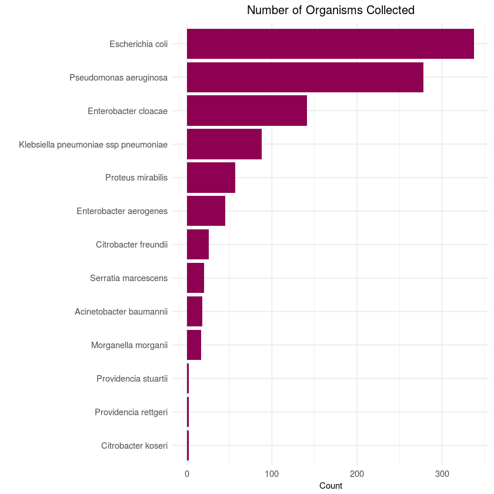

```r
## plot the organism counts from dataset
tmp = mdro %>% group_by(X) %>% summarize(cnt = n())
p1 <- ggplot(tmp, aes(x=reorder(X, cnt), y=cnt)) +
    geom_bar(stat="identity", fill=cols[2]) +
    theme_minimal() +
    coord_flip() +
    labs(title="Number of Organisms Collected", y="Count", x="") +
    theme(plot.title=element_text(hjust=0.5, size=12),
          axis.title.x=element_text(size=9))

p1
```

### Percent of organisms collected that are resistant to antibiotic.

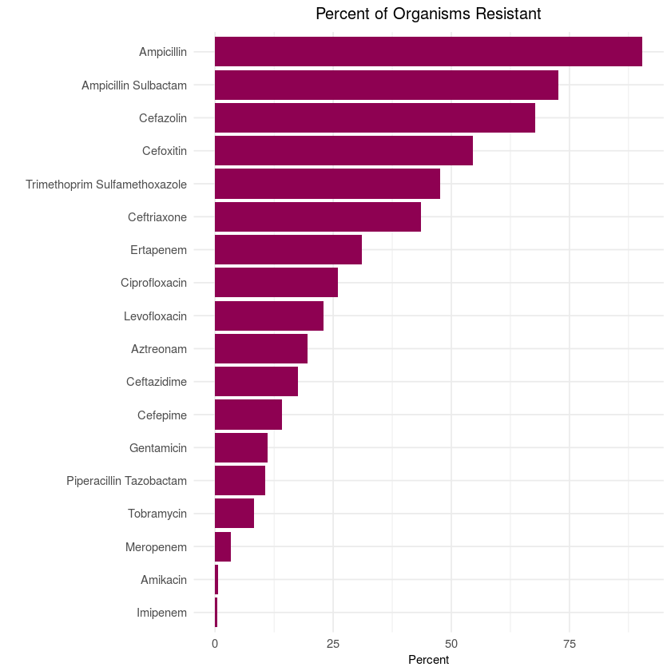

```r
## plot the fraction of organisms resistant to each antibiotic
tmp <- data.frame(colMeans(mdro[,3:20]))
tmp$abx <- rownames(tmp)
names(tmp) <- c('resistance', 'abx')

p2 <- ggplot(tmp, aes(x=reorder(gsub("\\.", " ",abx), resistance), y=resistance*100)) +
    geom_bar(stat='identity', fill=cols[2]) +
    coord_flip() +
    theme_minimal() +
    labs(title="Percent of Organisms Resistant", x="", y="Percent") +
    theme(plot.title=element_text(hjust=0.5, size=12),
          axis.title.x = element_text(size=9))

p2
```

### Heatmap of antibiotic resistance

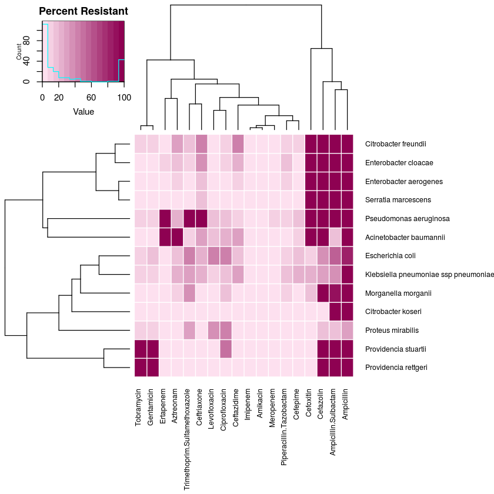

```r
## create a heatmap showing percent of organisms resistant to each antibiotic
tmp <- mdro[,c(1:20)] %>%
    melt(id.vars = c("X", "X.1")) %>%
    group_by(X) %>%
    mutate(total_count = length(unique(X.1))) %>%
    group_by(X, variable) %>%
    summarize(percent_resistant = sum(value)/mean(total_count)*100)

tmp <- tmp %>% dcast(X ~ variable, value.var = 'percent_resistant')
X <- as.matrix(tmp[,-1])
rownames(X) <- tmp$X

heatmap.2(X, cexRow=0.75, cexCol=.75,trace='none',
          key.title="Percent Resistant",
          col=col_ramp,
          sepwidth=c(0.005, 0.005),
          sepcolor='white',
          colsep=1:ncol(X),
          rowsep=1:nrow(X),
          margins=c(10,12))
```

### Describe Resistance using Chord Plot

This plot shows antibiotic resistance for each organism. The width of each band represents a fraction of a particular category. e.g. if you look at the antibiotic Ertapenem you can see that almost all of the resistance to ertapenem is attributed to Pseudomonas.

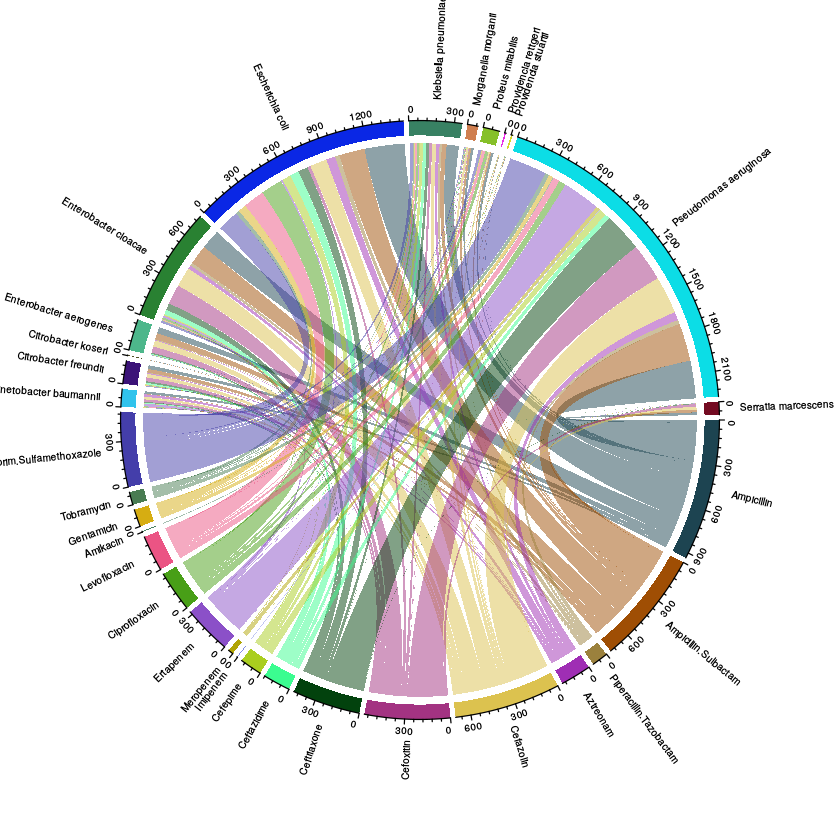

```r
## create chord diagram showing which bugs are resistant to which antibiotics
tmp <- mdro[,c(1,3:20)] %>% melt(id.vars = 'X') %>%
    filter(value == 1)
tmp <- with(tmp, table(variable, X))

set.seed(1234)
par(mar=c(0,0,0,0))
chordDiagram(as.data.frame(tmp), annotationTrack = "grid", preAllocateTracks = 1)
circos.trackPlotRegion(track.index = 1, panel.fun = function(x, y) {
  xlim = get.cell.meta.data("xlim")
  ylim = get.cell.meta.data("ylim")
  sector.name = get.cell.meta.data("sector.index")
  circos.text(mean(xlim), ylim[1] + .1, sector.name, facing = "clockwise", niceFacing = TRUE, adj = c(0, 0.5), cex=0.5)
  circos.axis(h = "top", labels.cex = 0.5, major.tick.percentage = 0.2, sector.index = sector.name, track.index = 2)
}, bg.border = NA)
```

### Describe Phenotypes

Here what I mean by phenotype is any particular pattern of resistance. I represent phenotypes as a pattern of 0's and 1's where 0's indicate sensitivity to that anibiotic and 1's represent resistance to that antibiotic. We tested 18 antibiotics so there are a total of $2^{18}=262,144$ possible phenotypes. However, we only find 201 unique phenotypes in our dataset. For example one of the Acinetobacters has a phenotype of `100111000001000000`. The order of antibiotics is `Ampicillin, Ampicillin.Sulbactam, Piperacillin.Tazobactam, Aztreonam, Cefazolin, Cefoxitin, Ceftriaxone, Ceftazidime, Cefepime, Imipenem, Meropenem, Ertapenem, Ciprofloxacin, Levofloxacin, Amikacin, Gentamicin, Tobramycin, Trimethoprim.Sulfamethoxazole`.

```r
## plot phenotype and number of antibiotics resistant for each phenotype for each organism
tmp <- mdro[,c(1,3:20)]
tmp$pt <- apply(tmp, 1, function(x) paste(x[-1], collapse=""))
tmp$total_res <- apply(mdro[,3:20], 1, sum)

tmp <- tmp %>% melt(id.vars = c('X', 'pt', 'total_res')) %>%
    group_by(X) %>%
    mutate(org_count = n()) %>%
    group_by(X, pt) %>%
    summarize(percent_pt = n()/mean(org_count),
              total_res = mean(total_res))

p3 <- ggplot(tmp, aes(x=reorder(pt, total_res), y=X, size=percent_pt, col=total_res)) +
    geom_point(alpha=1) +
    theme_minimal() +
    scale_size_continuous(name="Percent of organisms",
                          guide=guide_legend(title.position='top',
                                             title.hjust=0.5,
                                             override.aes=list(col=col_high))) +
    scale_color_continuous(low=col_low, high=col_high,
                           name="# Antibiotics",
                           guide=guide_legend(title.position="top",
                                              title.hjust=0.5)) +
    labs(x="Phenotypes",
         y="", title="Resistance Phenotypes") +
    theme(axis.text.x = element_blank(),
          panel.grid.major.x=element_blank(),
          panel.grid.minor.x=element_blank(),
          plot.title=element_text(hjust=0.5, size=12),
          legend.position = "bottom",
          axis.title.x = element_text(size=9))
```

### Plot phenotypes for each species and map number of antibiotics restistant to color

This plot shows the distribution of phenotypes for each species as well as the number of antibiotics each phenotype is resistant to (mapped to color...darker = more resistance). Phenotypes are sorted along the x-axis by increasing resistance (darker as we move to right). Size of each dot shows proportion of species that fall into that particular phenotype. It's interesting that some species seem to have much more phenotypic variability than others.

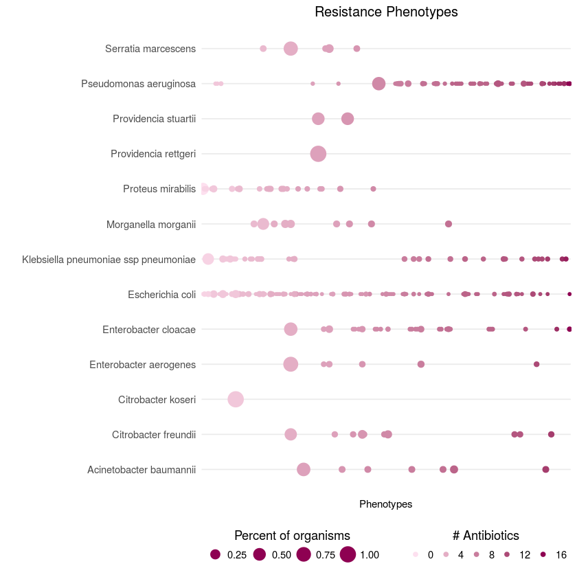

```r
p3
```

### Show the distribution of phenotypes for each species

This next plot shows similar information regarding the distribution of phenotypes for each species. For example, Providencia rettgeri has only one phenotype `110010000000000110`.

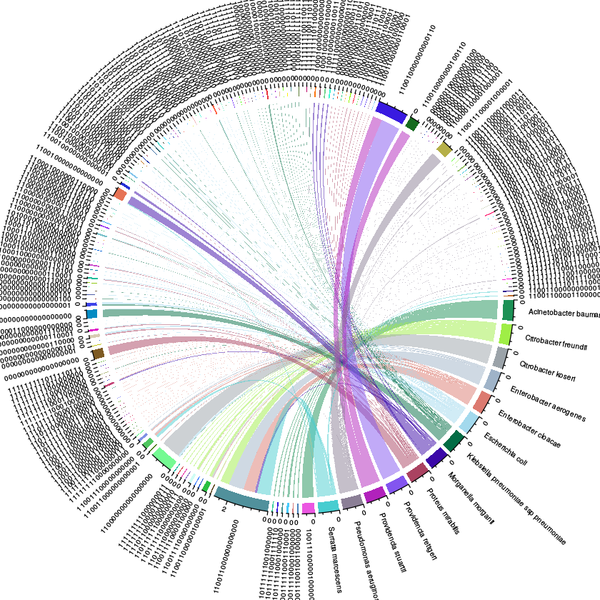

```r
## show the phenotypes for each organism species
set.seed(1234)
par(mar=c(0,0,0,0))
chordDiagram(as.data.frame(tmp), annotationTrack = "grid", preAllocateTracks = 1)
circos.trackPlotRegion(track.index = 1, panel.fun = function(x, y) {
  xlim = get.cell.meta.data("xlim")
  ylim = get.cell.meta.data("ylim")
  sector.name = get.cell.meta.data("sector.index")
  circos.text(mean(xlim), ylim[1] + .1, sector.name, facing = "clockwise", niceFacing = TRUE, adj = c(0, 0.5), cex=0.5)
  circos.axis(h = "top", labels.cex = 0.5, major.tick.percentage = 0.2, sector.index = sector.name, track.index = 2)
}, bg.border = NA)
```

### Put descriptive plots into single figure

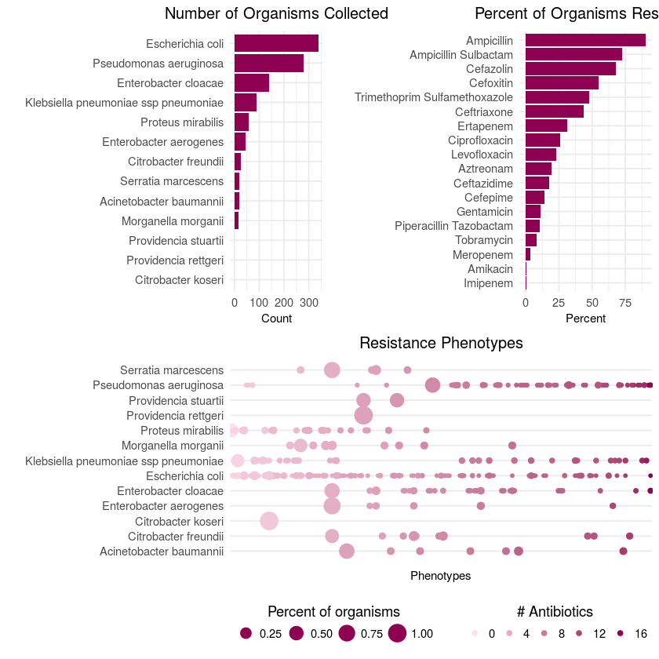

```r
## create a single figure using plots above
grid.arrange(p1, p2, p3, layout_matrix = matrix(c(1,2,3,3), nrow=2, byrow = T))
```

# Coparison of Definitions

1. Compare definitions using Cohen's kappa
2. Generate classification counts for each definition

### Compare definitions using Cohen's kappa

```r
library(psych, warn.conflicts = F, quietly = T)
```

```r
## compute kappa values for each pairwise combination of MDRO definitions
kappa_matrix <- function(X){
    n <- ncol(X)
    mat <- matrix(NA, n, n)
    for(i in 1:n){
        for(j in 1:n){
            mat[i,j] <- cohen.kappa(table(X[,i], X[,j]))$kappa
        }
    }
    rownames(mat) <- colnames(X)
    colnames(mat) <- colnames(X)
    mat
}
## select definition columns
defs_data <- mdro[,defs]
## compute kappas
kappa_mat <- kappa_matrix(defs_data)
```

### Plot a matrix of Kappa values showing all pairwise comparisons for each MDRO definition

This plot shows agreeming between definitions using Cohen's kappa, higher kappa (e.g. ~1) means higher agreement among the definitions in terms of which organisms are classified as MDRO. In other words, two definitions that have a high Kappa value tend to classify the same organisms as either MDRO or non-MDRO (the definitions agree with one another)

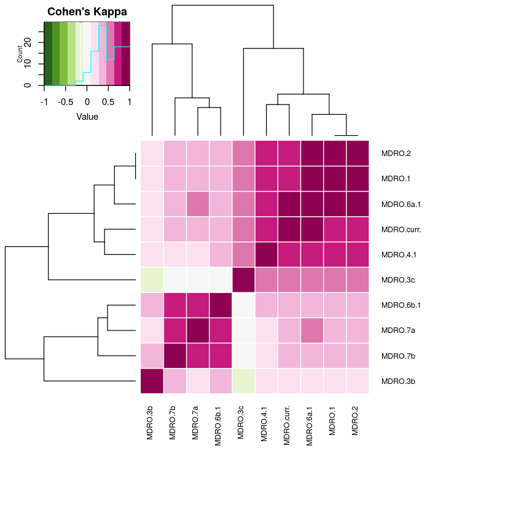

```r
## plot kappa values in heatmap
heatmap.2(kappa_mat, cexRow=0.75, cexCol=.75,trace='none',
          key.title="Cohen's Kappa",
          col=rev(brewer.pal(name="PiYG", n=11)),
          sepwidth=c(0.005, 0.005),
          sepcolor='white',
          colsep=1:ncol(kappa_mat),
          rowsep=1:ncol(kappa_mat),
          margins=c(10,12))
```

# Comparing Definitions according to Antibiotic Resistance Score

## Enterobacteriaceae/Acinetobacter

Here I calcualte the antibiotic resistance score for Enterobacteriaceae and Acinetobacter while excluding Pseudomoanas. This is so that Pseudomonas does not influence the weighting of each antibiotics. The antibotic resistance score is caluclated by the following $$R = \sum_{i=1}^{i=n} x_{i}w_{i}$$ where $x_{i}$ is 1 if organism is resistant to antibiotic $i$ and $w_{i}$ is the weight for antibiotic $i$. Antibiotics are weighted so that "stronger" antibiotics recieve a larger weight and "weaker" antibiotics recieve a lower weight. This *strength* of each antibiotic is calculated by $$w_i = 1-Q_i$$ where $Q_i$ is the fraction of organisms resistant to antibiotic $i$. Once resistance scores are calculated, we can look at each MDRO definition and plot the resistance score distribution among those organisms the definitions classifies as MDRO and those that it classifies as non-MDRO. This is shown below in the box-plots where the resistance score for is plotted on the y-axis and the different definitions are plotted on the x-axis. Also, there are two plots, one for Enterobacter/Acinetobacter and one for Pseudomonas

```r
# setup color palette
cols = brewer.pal(name="PiYG", n=11)
```

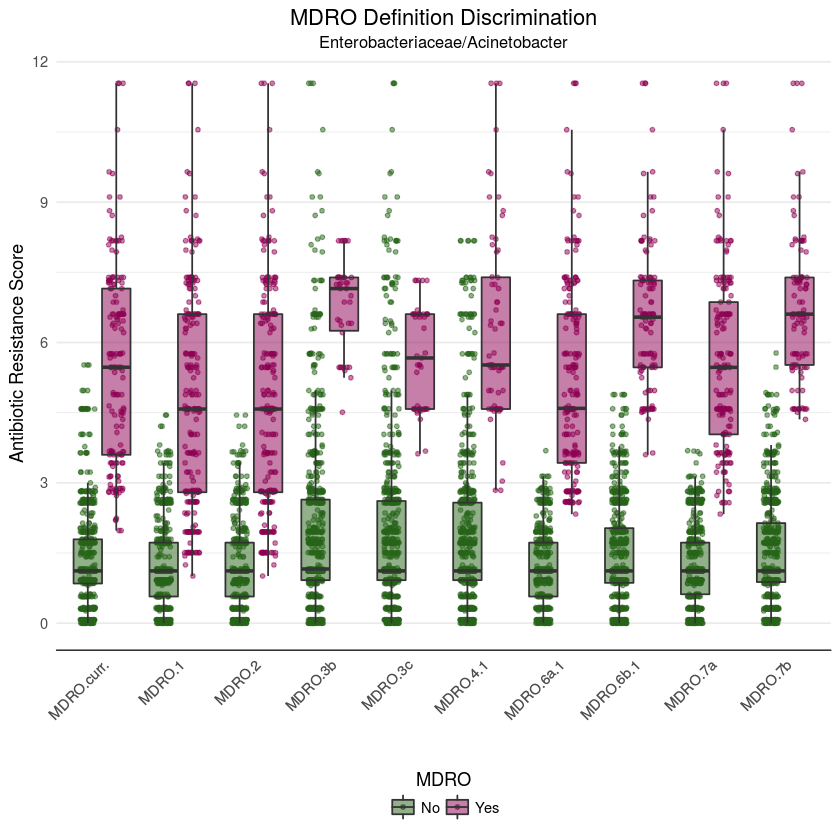

```r
## calculate antibiotic resistance score without Pseudomonas
ea <- subset(mdro, X != "Pseudomonas aeruginosa")
# get weights
ea_wts <- 1 - colMeans(do.call(rbind, by(ea[,3:20], list(ea$X), colMeans)))
# calc score
ea$abx_score <- as.matrix(ea[,3:20]) %*% ea_wts

## reshape abx_scores into long format
ea <- ea[,c("abx_score", defs)]  %>%
    melt(id.vars = "abx_score")

## plot antibiotic resistance score vs MDRO definition using boxplots - No Pseudomonas
p1 <- ggplot(ea, aes(x=variable, y=abx_score, fill=as.factor(value))) +
    geom_point(aes(col=as.factor(value)),
               position=position_jitterdodge(),
               alpha=0.5, size=1) +
    geom_boxplot(alpha=0.5,
                 outlier.size = NA) +
    scale_color_manual(values=c(cols[11], cols[1]), guide='none') +
    scale_fill_manual(values=c(cols[11], cols[1]),
                      name="MDRO",
                      labels = c('No', 'Yes'),
                      guide=guide_legend(position='bottom',
                                         title.position="top",
                                         title.hjust=0.5)) +
    labs(title="MDRO Definition Discrimination",
         subtitle="Enterobacteriaceae/Acinetobacter",
         x="",
         y="Antibiotic Resistance Score") +
    theme_minimal() +
    theme(legend.position = "bottom",
          axis.text.x=element_text(angle=45, hjust=1),
          panel.grid.minor.x = element_blank(),
          panel.grid.major.x = element_blank(),
          axis.line.x = element_line(),
          plot.title = element_text(hjust=0.5),
          plot.subtitle = element_text(hjust=0.5))
p1
```

## Pseudomonas

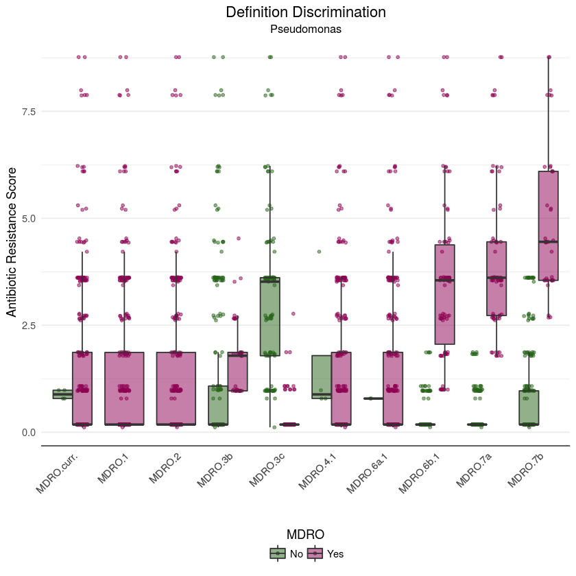

```r
## plot antibiotic resistance scores vs MDRO definiton using boxplots - Pseudomonas only
pseudo <- subset(mdro, X == 'Pseudomonas aeruginosa')
pseudo_wts <- (1 - colMeans(pseudo[,3:20]))
pseudo$abx_score <- as.matrix(pseudo[,3:20])%*%pseudo_wts
pseudo <- pseudo[,c("abx_score", defs)] %>%
    melt(id.vars = "abx_score")

p2 <- ggplot(pseudo, aes(x=variable, y=abx_score, fill=as.factor(value))) +
    geom_point(aes(col=as.factor(value)),
               position=position_jitterdodge(),
               alpha=0.5, size=1) +
    geom_boxplot(alpha=0.5,
                 outlier.size = NA) +

    scale_color_manual(values=c(cols[11], cols[1]), guide='none') +
    scale_fill_manual(values=c(cols[11], cols[1]), name="MDRO",
                      labels=c("No", "Yes"),
                      guide=guide_legend(title.position = 'top',
                                         title.hjust=0.5)) +
    labs(title="Definition Discrimination",
         subtitle="Pseudomonas",
         x="",
         y="Antibiotic Resistance Score") +
    theme_minimal() +
    theme(legend.position = "bottom",
          axis.text.x=element_text(angle=45, hjust=1),
          panel.grid.minor.x = element_blank(),
          panel.grid.major.x = element_blank(),
          axis.line.x = element_line(),
          plot.title = element_text(hjust=0.5),
          plot.subtitle = element_text(hjust=0.5))
p2
```

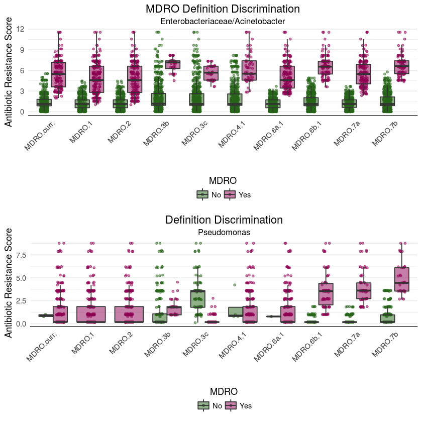

```r
## plot the Enterobacter/Acinetobacter and Pseusomonas figs in single plot
grid.arrange(p1, p2, ncol=1)
```